```python
from google.colab import drive
import pandas as pd
import numpy as np
import matplotlib.pyplot as plt
import seaborn as sns

# Mount Google Drive
drive.mount('/content/drive')

# Load data
file_path = '/content/drive/MyDrive/Colab Notebooks/Machine learning/CA2/kc_house_data.csv'

df = pd.read_csv(file_path)
```

# **Data overview**

- Check first 5 rows and headers of dataset.

```python
# Preview first 5 rows
df.head()
```

|  | id | date | price | bedrooms | bathrooms | sqft_living | sqft_lot | floors | waterfront | view | ... | grade | sqft_above | sqft_basement | yr_built | yr_renovated | zipcode | lat | long | sqft_living15 | sqft_lot15 |
| --- | --- | --- | --- | --- | --- | --- | --- | --- | --- | --- | --- | --- | --- | --- | --- | --- | --- | --- | --- | --- | --- |
| 0 | 7129300520 | 20141013T000000 | 221900.0 | 3 | 1.00 | 1180 | 5650 | 1.0 | 0 | 0 | ... | 7 | 1180 | 0 | 1955 | 0 | 98178 | 47.5112 | -122.257 | 1340 | 5650 |
| 1 | 6414100192 | 20141209T000000 | 538000.0 | 3 | 2.25 | 2570 | 7242 | 2.0 | 0 | 0 | ... | 7 | 2170 | 400 | 1951 | 1991 | 98125 | 47.7210 | -122.319 | 1690 | 7639 |
| 2 | 5631500400 | 20150225T000000 | 180000.0 | 2 | 1.00 | 770 | 10000 | 1.0 | 0 | 0 | ... | 6 | 770 | 0 | 1933 | 0 | 98028 | 47.7379 | -122.233 | 2720 | 8062 |
| 3 | 2487200875 | 20141209T000000 | 604000.0 | 4 | 3.00 | 1960 | 5000 | 1.0 | 0 | 0 | ... | 7 | 1050 | 910 | 1965 | 0 | 98136 | 47.5208 | -122.393 | 1360 | 5000 |
| 4 | 1954400510 | 20150218T000000 | 510000.0 | 3 | 2.00 | 1680 | 8080 | 1.0 | 0 | 0 | ... | 8 | 1680 | 0 | 1987 | 0 | 98074 | 47.6168 | -122.045 | 1800 | 7503 |

5 rows × 21 columns

# **Exploratory Data Analysis (EDA)**

- Check the dimension data to ensure it correct dimension.
- Here is 2 dimensional, it is correct.

```python
# Check the shape of dataset & find out total number of rows and columns (check if 1D or 2D)
df.shape
```

```
(21613, 21)
```

- Only 'date' column is catergorial/object, the rest of columns are numerical.

```python
# Identify categorical variables
df.info()
```

```
<class 'pandas.core.frame.DataFrame'>
RangeIndex: 21613 entries, 0 to 21612
Data columns (total 21 columns):
 #   Column         Non-Null Count  Dtype
---  ------         --------------  -----
 0   id             21613 non-null  int64
 1   date           21613 non-null  object
 2   price          21613 non-null  float64
 3   bedrooms       21613 non-null  int64
 4   bathrooms      21613 non-null  float64
 5   sqft_living    21613 non-null  int64
 6   sqft_lot       21613 non-null  int64
 7   floors         21613 non-null  float64
 8   waterfront     21613 non-null  int64
 9   view           21613 non-null  int64
 10  condition      21613 non-null  int64
 11  grade          21613 non-null  int64
 12  sqft_above     21613 non-null  int64
 13  sqft_basement  21613 non-null  int64
 14  yr_built       21613 non-null  int64
 15  yr_renovated   21613 non-null  int64
 16  zipcode        21613 non-null  int64
 17  lat            21613 non-null  float64
 18  long           21613 non-null  float64
 19  sqft_living15  21613 non-null  int64
 20  sqft_lot15     21613 non-null  int64
dtypes: float64(5), int64(15), object(1)
memory usage: 3.5+ MB
```

- There are no missing data.

```python
print('\n Missing values')
print(df.isna().sum().sort_values())
```

```
 Missing values
id               0
date             0
price            0
bedrooms         0
bathrooms        0
sqft_living      0
sqft_lot         0
floors           0
waterfront       0
view             0
condition        0
grade            0
sqft_above       0
sqft_basement    0
yr_built         0
yr_renovated     0
zipcode          0
lat              0
long             0
sqft_living15    0
sqft_lot15       0
dtype: int64
```

```python
# Extract the first 4 digits from the "date" column
df['purchased_year'] = df['date'].str[:4]
# Covert "purchased_year" column to interger because "date" column is string.
df['purchased_year'] = df['purchased_year'].astype(int)
print('Check the data type of "purchased_year" after converting to integer:')
print(df.dtypes)
# Drop 'date' column
df = df.drop(['date'], axis=1)
print('\nCheck the new column "purchased_year":')
df.head()
```

```
Check the data type of "purchased_year" after converting to integer:
id                  int64
date               object
price             float64
bedrooms            int64
bathrooms         float64
sqft_living         int64
sqft_lot            int64
floors            float64
waterfront          int64
view                int64
condition           int64
grade               int64
sqft_above          int64
sqft_basement       int64
yr_built            int64
yr_renovated        int64
zipcode             int64
lat               float64
long              float64
sqft_living15       int64
sqft_lot15          int64
purchased_year      int64
dtype: object

Check the new column "purchased_year":
```

|  | id | price | bedrooms | bathrooms | sqft_living | sqft_lot | floors | waterfront | view | condition | ... | sqft_above | sqft_basement | yr_built | yr_renovated | zipcode | lat | long | sqft_living15 | sqft_lot15 | purchased_year |
| --- | --- | --- | --- | --- | --- | --- | --- | --- | --- | --- | --- | --- | --- | --- | --- | --- | --- | --- | --- | --- | --- |
| 0 | 7129300520 | 221900.0 | 3 | 1.00 | 1180 | 5650 | 1.0 | 0 | 0 | 3 | ... | 1180 | 0 | 1955 | 0 | 98178 | 47.5112 | -122.257 | 1340 | 5650 | 2014 |
| 1 | 6414100192 | 538000.0 | 3 | 2.25 | 2570 | 7242 | 2.0 | 0 | 0 | 3 | ... | 2170 | 400 | 1951 | 1991 | 98125 | 47.7210 | -122.319 | 1690 | 7639 | 2014 |
| 2 | 5631500400 | 180000.0 | 2 | 1.00 | 770 | 10000 | 1.0 | 0 | 0 | 3 | ... | 770 | 0 | 1933 | 0 | 98028 | 47.7379 | -122.233 | 2720 | 8062 | 2015 |
| 3 | 2487200875 | 604000.0 | 4 | 3.00 | 1960 | 5000 | 1.0 | 0 | 0 | 5 | ... | 1050 | 910 | 1965 | 0 | 98136 | 47.5208 | -122.393 | 1360 | 5000 | 2014 |
| 4 | 1954400510 | 510000.0 | 3 | 2.00 | 1680 | 8080 | 1.0 | 0 | 0 | 3 | ... | 1680 | 0 | 1987 | 0 | 98074 | 47.6168 | -122.045 | 1800 | 7503 | 2015 |

5 rows × 21 columns

- Feature engineering: to make the data more meaningful, create 'house_age' column and remove 'purchased_year' and 'yr_built' column.

```python
df['house_age'] = df['purchased_year']-df['yr_built']
print('Check the data type of "house_age":')
print(df.dtypes)
print('\nCheck the new column "house_age":')
df.head()
```

```
Check the data type of "house_age":
id                  int64
price             float64
bedrooms            int64
bathrooms         float64
sqft_living         int64
sqft_lot            int64
floors            float64
waterfront          int64
view                int64
condition           int64
grade               int64
sqft_above          int64
sqft_basement       int64
yr_built            int64
yr_renovated        int64
zipcode             int64
lat               float64
long              float64
sqft_living15       int64
sqft_lot15          int64
purchased_year      int64
house_age           int64
dtype: object

Check the new column "house_age":
```

|  | id | price | bedrooms | bathrooms | sqft_living | sqft_lot | floors | waterfront | view | condition | ... | sqft_basement | yr_built | yr_renovated | zipcode | lat | long | sqft_living15 | sqft_lot15 | purchased_year | house_age |
| --- | --- | --- | --- | --- | --- | --- | --- | --- | --- | --- | --- | --- | --- | --- | --- | --- | --- | --- | --- | --- | --- |
| 0 | 7129300520 | 221900.0 | 3 | 1.00 | 1180 | 5650 | 1.0 | 0 | 0 | 3 | ... | 0 | 1955 | 0 | 98178 | 47.5112 | -122.257 | 1340 | 5650 | 2014 | 59 |
| 1 | 6414100192 | 538000.0 | 3 | 2.25 | 2570 | 7242 | 2.0 | 0 | 0 | 3 | ... | 400 | 1951 | 1991 | 98125 | 47.7210 | -122.319 | 1690 | 7639 | 2014 | 63 |
| 2 | 5631500400 | 180000.0 | 2 | 1.00 | 770 | 10000 | 1.0 | 0 | 0 | 3 | ... | 0 | 1933 | 0 | 98028 | 47.7379 | -122.233 | 2720 | 8062 | 2015 | 82 |
| 3 | 2487200875 | 604000.0 | 4 | 3.00 | 1960 | 5000 | 1.0 | 0 | 0 | 5 | ... | 910 | 1965 | 0 | 98136 | 47.5208 | -122.393 | 1360 | 5000 | 2014 | 49 |
| 4 | 1954400510 | 510000.0 | 3 | 2.00 | 1680 | 8080 | 1.0 | 0 | 0 | 3 | ... | 0 | 1987 | 0 | 98074 | 47.6168 | -122.045 | 1800 | 7503 | 2015 | 28 |

5 rows × 22 columns

- Feature engineering: to make the data more meaningful, create 'is_renovated' column and substitue year with 1 to represent the house is renovated.

```python
# Create binary 'is_renovated' column
df['is_renovated'] = (df['yr_renovated'] > 0).astype(int)
#Drop 'yr_renovated' column
df = df.drop(['yr_renovated'], axis=1)
print('\nCheck the data type of "is_renovated" column:')
print(df.dtypes)
df.head()
```

```
Check the data type of "is_renovated" column:
id                  int64
price             float64
bedrooms            int64
bathrooms         float64
sqft_living         int64
sqft_lot            int64
floors            float64
waterfront          int64
view                int64
condition           int64
grade               int64
sqft_above          int64
sqft_basement       int64
yr_built            int64
zipcode             int64
lat               float64
long              float64
sqft_living15       int64
sqft_lot15          int64
purchased_year      int64
house_age           int64
is_renovated        int64
dtype: object
```

|  | id | price | bedrooms | bathrooms | sqft_living | sqft_lot | floors | waterfront | view | condition | ... | sqft_basement | yr_built | zipcode | lat | long | sqft_living15 | sqft_lot15 | purchased_year | house_age | is_renovated |
| --- | --- | --- | --- | --- | --- | --- | --- | --- | --- | --- | --- | --- | --- | --- | --- | --- | --- | --- | --- | --- | --- |
| 0 | 7129300520 | 221900.0 | 3 | 1.00 | 1180 | 5650 | 1.0 | 0 | 0 | 3 | ... | 0 | 1955 | 98178 | 47.5112 | -122.257 | 1340 | 5650 | 2014 | 59 | 0 |
| 1 | 6414100192 | 538000.0 | 3 | 2.25 | 2570 | 7242 | 2.0 | 0 | 0 | 3 | ... | 400 | 1951 | 98125 | 47.7210 | -122.319 | 1690 | 7639 | 2014 | 63 | 1 |
| 2 | 5631500400 | 180000.0 | 2 | 1.00 | 770 | 10000 | 1.0 | 0 | 0 | 3 | ... | 0 | 1933 | 98028 | 47.7379 | -122.233 | 2720 | 8062 | 2015 | 82 | 0 |
| 3 | 2487200875 | 604000.0 | 4 | 3.00 | 1960 | 5000 | 1.0 | 0 | 0 | 5 | ... | 910 | 1965 | 98136 | 47.5208 | -122.393 | 1360 | 5000 | 2014 | 49 | 0 |
| 4 | 1954400510 | 510000.0 | 3 | 2.00 | 1680 | 8080 | 1.0 | 0 | 0 | 3 | ... | 0 | 1987 | 98074 | 47.6168 | -122.045 | 1800 | 7503 | 2015 | 28 | 0 |

5 rows × 22 columns

- Convert 'is_renovated' column to boolean data type using dummies.

```python
# apply get_dummies for 'is_renovated' column
is_renovated_dummy_df = pd.get_dummies(df['is_renovated'], drop_first = True)
is_renovated_dummy_df.head()
```

|  | 1 |
| --- | --- |
| 0 | False |
| 1 | True |
| 2 | False |
| 3 | False |
| 4 | False |

- Join back the boolean data type of 'is_renovated' column to the dataset

```python
# join is_renovated_dummy_df back to df dataset
df = pd.concat([df, is_renovated_dummy_df.add_prefix('is_renovated_')], axis=1)
# drop 'is_renovated' column
df = df.drop(['is_renovated'], axis=1)
df.head()
```

|  | id | price | bedrooms | bathrooms | sqft_living | sqft_lot | floors | waterfront | view | condition | ... | sqft_basement | yr_built | zipcode | lat | long | sqft_living15 | sqft_lot15 | purchased_year | house_age | is_renovated_1 |
| --- | --- | --- | --- | --- | --- | --- | --- | --- | --- | --- | --- | --- | --- | --- | --- | --- | --- | --- | --- | --- | --- |
| 0 | 7129300520 | 221900.0 | 3 | 1.00 | 1180 | 5650 | 1.0 | 0 | 0 | 3 | ... | 0 | 1955 | 98178 | 47.5112 | -122.257 | 1340 | 5650 | 2014 | 59 | False |
| 1 | 6414100192 | 538000.0 | 3 | 2.25 | 2570 | 7242 | 2.0 | 0 | 0 | 3 | ... | 400 | 1951 | 98125 | 47.7210 | -122.319 | 1690 | 7639 | 2014 | 63 | True |
| 2 | 5631500400 | 180000.0 | 2 | 1.00 | 770 | 10000 | 1.0 | 0 | 0 | 3 | ... | 0 | 1933 | 98028 | 47.7379 | -122.233 | 2720 | 8062 | 2015 | 82 | False |
| 3 | 2487200875 | 604000.0 | 4 | 3.00 | 1960 | 5000 | 1.0 | 0 | 0 | 5 | ... | 910 | 1965 | 98136 | 47.5208 | -122.393 | 1360 | 5000 | 2014 | 49 | False |
| 4 | 1954400510 | 510000.0 | 3 | 2.00 | 1680 | 8080 | 1.0 | 0 | 0 | 3 | ... | 0 | 1987 | 98074 | 47.6168 | -122.045 | 1800 | 7503 | 2015 | 28 | False |

5 rows × 22 columns

- Convert 'waterfront' column to boolean data type using dummies.

```python
# apply get_dummies for 'waterfront' column
waterfront_dummy_df = pd.get_dummies(df['waterfront'], drop_first = True)
waterfront_dummy_df.head()
```

|  | 1 |
| --- | --- |
| 0 | False |
| 1 | False |
| 2 | False |
| 3 | False |
| 4 | False |

- Join back the boolean data type of 'waterfront' column to the dataset

```python
# join waterfront_dummy_df back to df
df = pd.concat([df, waterfront_dummy_df.add_prefix('waterfront_')], axis=1)
# drop 'waterfront' column
df = df.drop(['waterfront'], axis=1)
df.head()
```

|  | id | price | bedrooms | bathrooms | sqft_living | sqft_lot | floors | view | condition | grade | ... | yr_built | zipcode | lat | long | sqft_living15 | sqft_lot15 | purchased_year | house_age | is_renovated_1 | waterfront_1 |
| --- | --- | --- | --- | --- | --- | --- | --- | --- | --- | --- | --- | --- | --- | --- | --- | --- | --- | --- | --- | --- | --- |
| 0 | 7129300520 | 221900.0 | 3 | 1.00 | 1180 | 5650 | 1.0 | 0 | 3 | 7 | ... | 1955 | 98178 | 47.5112 | -122.257 | 1340 | 5650 | 2014 | 59 | False | False |
| 1 | 6414100192 | 538000.0 | 3 | 2.25 | 2570 | 7242 | 2.0 | 0 | 3 | 7 | ... | 1951 | 98125 | 47.7210 | -122.319 | 1690 | 7639 | 2014 | 63 | True | False |
| 2 | 5631500400 | 180000.0 | 2 | 1.00 | 770 | 10000 | 1.0 | 0 | 3 | 6 | ... | 1933 | 98028 | 47.7379 | -122.233 | 2720 | 8062 | 2015 | 82 | False | False |
| 3 | 2487200875 | 604000.0 | 4 | 3.00 | 1960 | 5000 | 1.0 | 0 | 5 | 7 | ... | 1965 | 98136 | 47.5208 | -122.393 | 1360 | 5000 | 2014 | 49 | False | False |
| 4 | 1954400510 | 510000.0 | 3 | 2.00 | 1680 | 8080 | 1.0 | 0 | 3 | 8 | ... | 1987 | 98074 | 47.6168 | -122.045 | 1800 | 7503 | 2015 | 28 | False | False |

5 rows × 22 columns

- Check if scaling is required for big different range in numerical features.
- There are big different range such as 'sqft_living' and 'sqft_lot' columns

```python
df.describe()
```

|  | id | price | bedrooms | bathrooms | sqft_living | sqft_lot | floors | view | condition | grade | sqft_above | sqft_basement | yr_built | zipcode | lat | long | sqft_living15 | sqft_lot15 | purchased_year | house_age |
| --- | --- | --- | --- | --- | --- | --- | --- | --- | --- | --- | --- | --- | --- | --- | --- | --- | --- | --- | --- | --- |
| count | 2.161300e+04 | 2.161300e+04 | 21613.000000 | 21613.000000 | 21613.000000 | 2.161300e+04 | 21613.000000 | 21613.000000 | 21613.000000 | 21613.000000 | 21613.000000 | 21613.000000 | 21613.000000 | 21613.000000 | 21613.000000 | 21613.000000 | 21613.000000 | 21613.000000 | 21613.000000 | 21613.000000 |
| mean | 4.580302e+09 | 5.400881e+05 | 3.370842 | 2.114757 | 2079.899736 | 1.510697e+04 | 1.494309 | 0.234303 | 3.409430 | 7.656873 | 1788.390691 | 291.509045 | 1971.005136 | 98077.939805 | 47.560053 | -122.213896 | 1986.552492 | 12768.455652 | 2014.322954 | 43.317818 |
| std | 2.876566e+09 | 3.671272e+05 | 0.930062 | 0.770163 | 918.440897 | 4.142051e+04 | 0.539989 | 0.766318 | 0.650743 | 1.175459 | 828.090978 | 442.575043 | 29.373411 | 53.505026 | 0.138564 | 0.140828 | 685.391304 | 27304.179631 | 0.467616 | 29.375493 |
| min | 1.000102e+06 | 7.500000e+04 | 0.000000 | 0.000000 | 290.000000 | 5.200000e+02 | 1.000000 | 0.000000 | 1.000000 | 1.000000 | 290.000000 | 0.000000 | 1900.000000 | 98001.000000 | 47.155900 | -122.519000 | 399.000000 | 651.000000 | 2014.000000 | -1.000000 |
| 25% | 2.123049e+09 | 3.219500e+05 | 3.000000 | 1.750000 | 1427.000000 | 5.040000e+03 | 1.000000 | 0.000000 | 3.000000 | 7.000000 | 1190.000000 | 0.000000 | 1951.000000 | 98033.000000 | 47.471000 | -122.328000 | 1490.000000 | 5100.000000 | 2014.000000 | 18.000000 |
| 50% | 3.904930e+09 | 4.500000e+05 | 3.000000 | 2.250000 | 1910.000000 | 7.618000e+03 | 1.500000 | 0.000000 | 3.000000 | 7.000000 | 1560.000000 | 0.000000 | 1975.000000 | 98065.000000 | 47.571800 | -122.230000 | 1840.000000 | 7620.000000 | 2014.000000 | 40.000000 |
| 75% | 7.308900e+09 | 6.450000e+05 | 4.000000 | 2.500000 | 2550.000000 | 1.068800e+04 | 2.000000 | 0.000000 | 4.000000 | 8.000000 | 2210.000000 | 560.000000 | 1997.000000 | 98118.000000 | 47.678000 | -122.125000 | 2360.000000 | 10083.000000 | 2015.000000 | 63.000000 |
| max | 9.900000e+09 | 7.700000e+06 | 33.000000 | 8.000000 | 13540.000000 | 1.651359e+06 | 3.500000 | 4.000000 | 5.000000 | 13.000000 | 9410.000000 | 4820.000000 | 2015.000000 | 98199.000000 | 47.777600 | -121.315000 | 6210.000000 | 871200.000000 | 2015.000000 | 115.000000 |

- Create box plot to check outliers of numerical features.
- 'sqft_lot' has a lot of outliers.

```
Check outliers of numerical (continuous variables) variables:
```

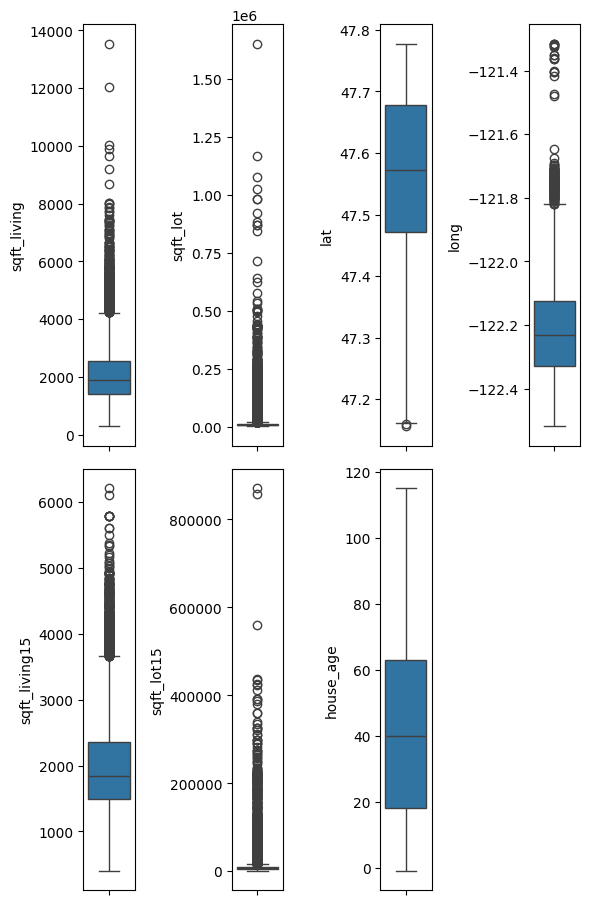

```python
print('Check outliers of numerical (continuous variables) variables:')
features = ['sqft_living', 'sqft_lot', 'lat', 'long', 'sqft_living15', 'sqft_lot15', 'house_age']
plt.figure(figsize=(6, 18)) # 6 inches wide and 18 inches tall
for i, col in enumerate(features):
    plt.subplot(4, 4, i + 1)  # Grid with 2 rows and 3 columns (for a total of 6 possible subplot positions).
    sns.boxplot(y=df[col]) # Specify the data to be plotted, df is self-created dataset name in above (df = pd.read_csv(file_path)).
# plt.suptitle('Box plots of Features')
plt.tight_layout()
plt.show()
```

- Check distribution of numerical features with histograms.
- 'sqft_living' column is right-skew.

```
Distribution plots for numerical (continuous variables) features
```

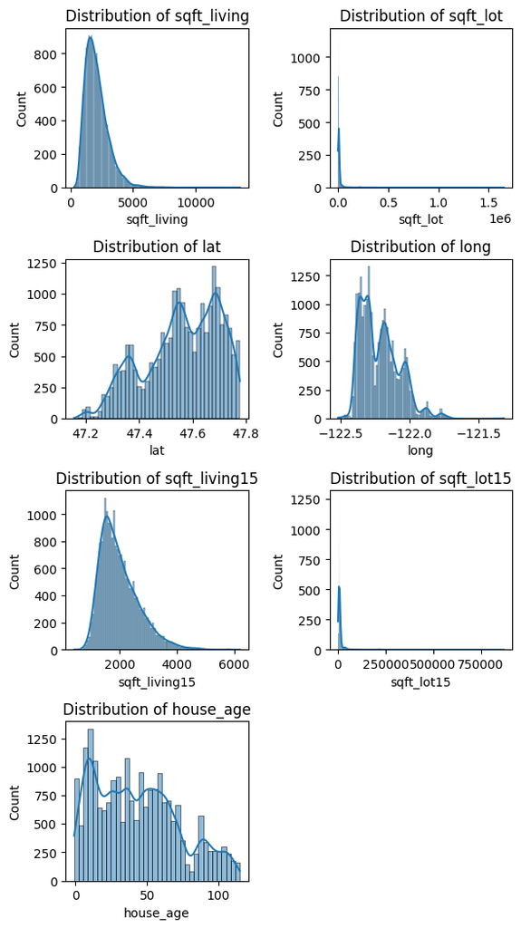

```python
# Check distribution-skewness with Density Plots with histograms)
print('Distribution plots for numerical (continuous variables) features')
features = ['sqft_living', 'sqft_lot', 'lat', 'long', 'sqft_living15', 'sqft_lot15', 'house_age']
plt.figure(figsize=(6, 18))
for i, col in enumerate(features):
    plt.subplot(7, 2, i + 1)  # Grid with 2 rows and 3 columns (for a total of 6 possible subplot positions).
    sns.histplot(df[col], kde=True, bins='auto') # KDE stands for Kernel Density Estimate. It is a curve to visualize the probability density function. bins='auto' is auto choose number of bi.
    plt.title(f'Distribution of {col}')
# plt.suptitle('Distribution Plots of Numerical Features')
plt.tight_layout()
plt.show()
```

- To check if imbalance data exits.

```
Numerical (discrete variables) features distribution:
```

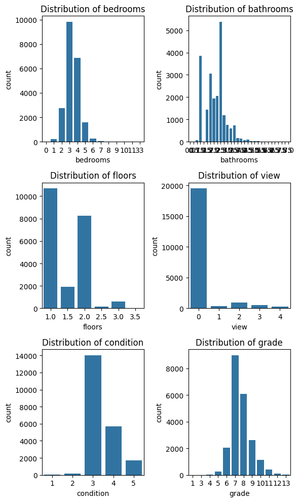

```python
# Numerical (discrete variables) features distribution
print('Numerical (discrete variables) features distribution:')
features = ['bedrooms','bathrooms', 'floors', 'view', 'condition', 'grade']
plt.figure(figsize=(6, 10))
for i, col in enumerate(features):
    plt.subplot(3, 2, i + 1)  # plt.subplot(number_of_rows, number_of_columns, plot_number). Plot numbers start from 1, not 0.
    sns.countplot(x=col, data=df)
    plt.title(f'Distribution of {col}')
plt.tight_layout()
plt.show()
```

- Create box plot to check outliers of target (dependent) variable.

```
Create box plot to check outliers of target (dependent) variable:
Target variable distribution (Price):
```

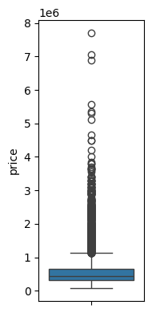

```python
print('Create box plot to check outliers of target (dependent) variable:')
# Target (dependent) variable distribution
print('Target variable distribution (Price):')
plt.figure(figsize=(2, 4)) # 10 inches wide and 8 inches tall
sns.boxplot(y=df['price']) # Specify the data to be plotted, df is self-created dataset name in above (df = pd.read_csv(file_path)).
plt.tight_layout()
plt.show()
```

- Check distribution of target (dependent) variable with histograms.
- 'price' column is right-skewed.

```
Distribution plots for target (dependent) variable
```

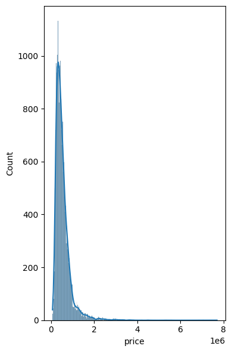

```python
# Check price distribution-skewness with Density Plots with histograms)
print('\nDistribution plots for target (dependent) variable')
plt.figure(figsize=(4, 6))
sns.histplot(df['price'], kde=True, bins='auto')
plt.tight_layout()
plt.show()
```

# **Data cleaning**

- Remove the rows with typo (-1) in 'house_age' column

```python
# drop all the rows with -1 in house_age column (year built is later than documentation date)
df_cleaned = df[df['house_age'] != -1]
```

- Drop/remove redundant features from the dataset that might create noise when modeling.

```python
# Remove redundant features from the dataset that might create noise when modeling
print('Performing data cleaning (drop redundant features):')
df_cleaned = df_cleaned.drop(['id',  'sqft_above', 'sqft_basement', 'yr_built', 'zipcode', 'purchased_year'], axis=1)
# Preview first 5 rows to confirm
df_cleaned.head()
```

```
Performing data cleaning (drop redundant features):
```

|  | price | bedrooms | bathrooms | sqft_living | sqft_lot | floors | view | condition | grade | lat | long | sqft_living15 | sqft_lot15 | house_age | is_renovated_1 | waterfront_1 |
| --- | --- | --- | --- | --- | --- | --- | --- | --- | --- | --- | --- | --- | --- | --- | --- | --- |
| 0 | 221900.0 | 3 | 1.00 | 1180 | 5650 | 1.0 | 0 | 3 | 7 | 47.5112 | -122.257 | 1340 | 5650 | 59 | False | False |
| 1 | 538000.0 | 3 | 2.25 | 2570 | 7242 | 2.0 | 0 | 3 | 7 | 47.7210 | -122.319 | 1690 | 7639 | 63 | True | False |
| 2 | 180000.0 | 2 | 1.00 | 770 | 10000 | 1.0 | 0 | 3 | 6 | 47.7379 | -122.233 | 2720 | 8062 | 82 | False | False |
| 3 | 604000.0 | 4 | 3.00 | 1960 | 5000 | 1.0 | 0 | 5 | 7 | 47.5208 | -122.393 | 1360 | 5000 | 49 | False | False |
| 4 | 510000.0 | 3 | 2.00 | 1680 | 8080 | 1.0 | 0 | 3 | 8 | 47.6168 | -122.045 | 1800 | 7503 | 28 | False | False |

- Use heatmap to find the high correlated features.
- Here 0.75 above is considered as high correlated
- 'bathrooms', 'grade' and 'sqft_living15' are 0.75 above.

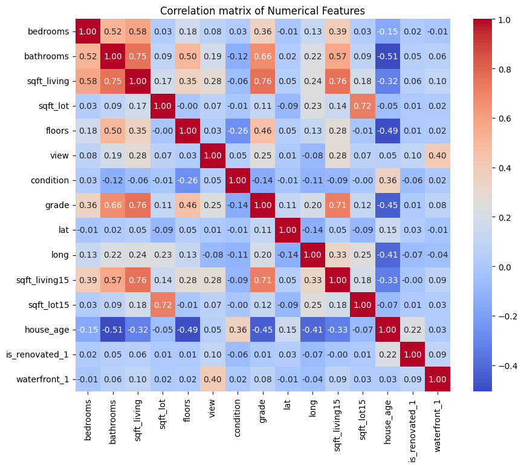

```python
# Heatmap
corr_matrix = df_cleaned[['bedrooms', 'bathrooms', 'sqft_living', 'sqft_lot', 'floors', 'view', 'condition', 'grade', 'lat', 'long', 'sqft_living15', 'sqft_lot15', 'house_age', 'is_renovated_1', 'waterfront_1']].corr()
# print(corr_matrix)
corr_matrix
plt.figure(figsize=(10, 8))
sns.heatmap(corr_matrix, annot=True, cmap='coolwarm', fmt=".2f")
plt.title('Correlation matrix of Numerical Features')
plt.show()
```

- Drop 'bathrooms', 'grade' and 'sqft_living15' columns.

```python
# Remove correlated features from the dataset that might create noise when modeling
print('Data cleaning (drop correlated features):')
df_cleaned = df_cleaned.drop(['bathrooms', 'grade', 'sqft_living15'], axis=1)
# Preview first 5 rows to confirm
df_cleaned.head()
```

```
Data cleaning (drop correlated features):
```

|  | price | bedrooms | sqft_living | sqft_lot | floors | view | condition | lat | long | sqft_lot15 | house_age | is_renovated_1 | waterfront_1 |
| --- | --- | --- | --- | --- | --- | --- | --- | --- | --- | --- | --- | --- | --- |
| 0 | 221900.0 | 3 | 1180 | 5650 | 1.0 | 0 | 3 | 47.5112 | -122.257 | 5650 | 59 | False | False |
| 1 | 538000.0 | 3 | 2570 | 7242 | 2.0 | 0 | 3 | 47.7210 | -122.319 | 7639 | 63 | True | False |
| 2 | 180000.0 | 2 | 770 | 10000 | 1.0 | 0 | 3 | 47.7379 | -122.233 | 8062 | 82 | False | False |
| 3 | 604000.0 | 4 | 1960 | 5000 | 1.0 | 0 | 5 | 47.5208 | -122.393 | 5000 | 49 | False | False |
| 4 | 510000.0 | 3 | 1680 | 8080 | 1.0 | 0 | 3 | 47.6168 | -122.045 | 7503 | 28 | False | False |

- Recheck if any big different range after data cleaning.
- There are big different range such as 'sqft_lot' and 'view' columns.

```python
df_cleaned.describe()
```

|  | price | bedrooms | sqft_living | sqft_lot | floors | view | condition | lat | long | sqft_lot15 | house_age |
| --- | --- | --- | --- | --- | --- | --- | --- | --- | --- | --- | --- |
| count | 2.160100e+04 | 21601.000000 | 21601.000000 | 2.160100e+04 | 21601.000000 | 21601.000000 | 21601.000000 | 21601.000000 | 21601.000000 | 21601.000000 | 21601.000000 |
| mean | 5.401295e+05 | 3.370909 | 2079.835332 | 1.511319e+04 | 1.493866 | 0.234341 | 3.409657 | 47.560008 | -122.213844 | 12772.457664 | 43.342438 |
| std | 3.672153e+05 | 0.929812 | 918.264931 | 4.143112e+04 | 0.539673 | 0.766418 | 0.650852 | 0.138582 | 0.140843 | 27311.041452 | 29.365068 |
| min | 7.500000e+04 | 0.000000 | 290.000000 | 5.200000e+02 | 1.000000 | 0.000000 | 1.000000 | 47.155900 | -122.519000 | 651.000000 | 0.000000 |
| 25% | 3.215000e+05 | 3.000000 | 1430.000000 | 5.042000e+03 | 1.000000 | 0.000000 | 3.000000 | 47.470800 | -122.328000 | 5100.000000 | 18.000000 |
| 50% | 4.500000e+05 | 3.000000 | 1910.000000 | 7.620000e+03 | 1.500000 | 0.000000 | 3.000000 | 47.571700 | -122.230000 | 7620.000000 | 40.000000 |
| 75% | 6.450000e+05 | 4.000000 | 2550.000000 | 1.069600e+04 | 2.000000 | 0.000000 | 4.000000 | 47.678000 | -122.125000 | 10086.000000 | 63.000000 |
| max | 7.700000e+06 | 33.000000 | 13540.000000 | 1.651359e+06 | 3.500000 | 4.000000 | 5.000000 | 47.777600 | -121.315000 | 871200.000000 | 115.000000 |

**Spliting the data**

- Define features (X) and target (y)
- - X is features without price
- - y is price
- The prediction task is to predict the house price.

```python
from sklearn.model_selection import train_test_split

# 1) Define features (X) and target (y)
X = df_cleaned.drop('price', axis=1)
y = df_cleaned['price']
```

- Split the data into 80% for training set and 20% for testing set before taining and testing to prevent data leakage.

```python
# Split the data (X, y) into Training and Testing sets first to prevent data leakage
X_train, X_test, y_train, y_test = train_test_split(X, y, test_size=0.2, random_state=42) # 'stratify=y' is not required because only for classification model

print('Check the shape of train and test datasets after spliting')
print(f'X shape: {X.shape}')
print(f'X_train shape: {X_train.shape}')
print(f'X_test shape: {X_test.shape}')
```

```
Check the shape of train and test datasets after spliting
X shape: (21601, 12)
X_train shape: (17280, 12)
X_test shape: (4321, 12)
```

**Evaluating regression models**

```python
#**Cross-Validation Performance**
from sklearn.model_selection import cross_val_score, KFold
from sklearn.linear_model import LinearRegression
from sklearn.neighbors import KNeighborsRegressor
from sklearn.tree import DecisionTreeRegressor
from sklearn.ensemble import RandomForestRegressor

kf = KFold(n_splits=6, shuffle=True, random_state=42)

# Cross-validation performance of Linear Regression
print('Cross-validation performance of Linear Regression')
linear_regression = LinearRegression()
cv_results_lin_reg = cross_val_score(linear_regression, X, y, cv=kf)
print(f'6 folds of R² scores: {cv_results_lin_reg}')
print('Mean & standard deviation of R² score for all 6 folds:')
print(np.mean(cv_results_lin_reg), np.std(cv_results_lin_reg))
print('The 2.5th percentile and 97.5th percentile of R² scores:')
print(np.quantile(cv_results_lin_reg, [0.025, 0.975])) # We can 95% confident that the true performance of Linear Regression model on new, unseen data lies between approximately 2.5th percentile and 97.5th percentile)

# Cross-validation performance of KNeighbors Regressor
print('\nCross-validation performance of KNeighbors Regressor')
knei_reg = KNeighborsRegressor()
cv_results_knei_reg = cross_val_score(knei_reg, X, y, cv=kf)
print(f'6 folds of R² scores: {cv_results_knei_reg}')
print('Mean & standard deviation of R² score for all 6 folds:')
print(np.mean(cv_results_knei_reg), np.std(cv_results_knei_reg))
print('The 2.5th percentile and 97.5th percentile of R² scores:')
print(np.quantile(cv_results_knei_reg, [0.025, 0.975]))

# Cross-validation performance of Decision Tree Regressor
print('\nCross-validation performance of Decision Tree Regressor')
dec_tre_reg = DecisionTreeRegressor()
cv_results_dec_tre_reg = cross_val_score(dec_tre_reg, X, y, cv=kf)
print(f'6 folds of R² scores: {cv_results_dec_tre_reg}')
print('Mean & standard deviation of R² score for all 6 folds:')
print(np.mean(cv_results_dec_tre_reg), np.std(cv_results_dec_tre_reg))
print('The 2.5th percentile and 97.5th percentile of R² scores:')
print(np.quantile(cv_results_dec_tre_reg, [0.025, 0.975]))

# Cross-validation performance of Random Forest Regressor
print('\nCross-validation performance of Random Forest Regressor')
Random_Forest_Regressor = RandomForestRegressor()
cv_results_ran_for_reg = cross_val_score(Random_Forest_Regressor, X, y, cv=kf)
print(f'6 folds of R² scores: {cv_results_ran_for_reg}')
print('Mean & standard deviation of R² score for all 6 folds:')
print(np.mean(cv_results_ran_for_reg), np.std(cv_results_ran_for_reg))
print('The 2.5th percentile and 97.5th percentile of R² scores:')
print(np.quantile(cv_results_ran_for_reg, [0.025, 0.975])) # We can 95% confident that the true performance of Random Forest Regressor model on new, unseen data lies between approximately 2.5th percentile and 97.5th percentile
```

```
Cross-validation performance of Linear Regression
6 folds of R² scores: [0.66105715 0.64207758 0.65090557 0.65413431 0.6402708  0.65563675]
Mean & standard deviation of R² score for all 6 folds:
0.6506803597554808 0.007377791370876383
The 2.5th percentile and 97.5th percentile of R² scores:
[0.64049665 0.6603796 ]

Cross-validation performance of KNeighbors Regressor
6 folds of R² scores: [0.4430008  0.45134168 0.44237433 0.41677246 0.45134022 0.41963783]
Mean & standard deviation of R² score for all 6 folds:
0.4374112191439536 0.01405822481737281
The 2.5th percentile and 97.5th percentile of R² scores:
[0.41713063 0.4513415 ]

Cross-validation performance of Decision Tree Regressor
6 folds of R² scores: [0.78612006 0.73872502 0.77310385 0.72001108 0.69537308 0.72096824]
Mean & standard deviation of R² score for all 6 folds:
0.7390502231614989 0.03155013345727959
The 2.5th percentile and 97.5th percentile of R² scores:
[0.69845283 0.78449304]

Cross-validation performance of Random Forest Regressor
6 folds of R² scores: [0.87851845 0.8772349  0.87114492 0.87612393 0.83795804 0.84356054]
Mean & standard deviation of R² score for all 6 folds:
0.8640901286661772 0.01673267385181667
The 2.5th percentile and 97.5th percentile of R² scores:
[0.83865835 0.87835801]
```

**Preprocessing**

- Create pipelines for standardization purpose for big range in numerical features.

```python
from sklearn.impute import SimpleImputer
from sklearn.preprocessing import StandardScaler, OneHotEncoder
from sklearn.compose import ColumnTransformer
from sklearn.pipeline import Pipeline
from sklearn.ensemble import RandomForestRegressor
from sklearn.metrics import mean_squared_error

# Create preprocessing pipelines
standardscaler_pipeline = Pipeline(steps=[
    ('scaler', StandardScaler())
])

df_cleaned_features = ['bedrooms', 'sqft_living', 'sqft_lot', 'floors', 'view', 'condition', 'lat', 'long', 'sqft_lot15', 'house_age']

# Use ColumnTransformer to apply preprocessing pipelines to the correct columns
preprocessor = ColumnTransformer(
    transformers=[
        ('num_standardscaler_transform', standardscaler_pipeline, df_cleaned_features)
    ],
    remainder='drop' # Any columns in dataset that are not explicitly mentioned in the transformers list will be dropped.
)

# Integrate into a full pipeline with RandomForestRegressor model.
ranforreg_full_pipeline = Pipeline(steps=[
    ('preprocessor', preprocessor),
    ('random_forest_regressor', RandomForestRegressor())
])
```

## **Hyperparameter tuning (GridSearchCV)**

RandomForestRegressor

- Find the best parameter for the best model (Random Forest Regressor)

```python
from sklearn.model_selection import train_test_split, GridSearchCV
from sklearn.metrics import accuracy_score, classification_report, confusion_matrix
from sklearn.metrics import mean_squared_error, r2_score

param_grid_ran_for_reg = {
    'random_forest_regressor__n_estimators': [50, 100],
    'random_forest_regressor__max_depth': [10, 20],
    'random_forest_regressor__min_samples_split': [2, 4],
    'random_forest_regressor__min_samples_leaf': [1, 2]
}

grid_search_ran_for_reg = GridSearchCV(ranforreg_full_pipeline, param_grid_ran_for_reg, cv=4)
grid_search_ran_for_reg.fit(X_train, y_train)

print(f'Best parameters of Random Forest Regressor: {grid_search_ran_for_reg.best_params_}')
print(f'Best cross-validation accuracy for Random Forest Regressor: {grid_search_ran_for_reg.best_score_:.3f}') # with best combination of hyperparameters

r_squared_ran_for_reg = grid_search_ran_for_reg.score(X_test, y_test)
print(f'R-squared of Random Forest Regressor:{r_squared_ran_for_reg: .4f}')

y_pred_ran_for_reg = grid_search_ran_for_reg.predict(X_test)
mse_ran_for_reg = mean_squared_error(y_test, y_pred_ran_for_reg)
rmse_ran_for_reg = np.sqrt(mse_ran_for_reg)

print(f'RMSE of Random Forest Regressor: {rmse_ran_for_reg: .4f}')
```

```
Best parameters of Random Forest Regressor: {'random_forest_regressor__max_depth': 20, 'random_forest_regressor__min_samples_leaf': 1, 'random_forest_regressor__min_samples_split': 4, 'random_forest_regressor__n_estimators': 100}
Best cross-validation accuracy for Random Forest Regressor: 0.839
R-squared of Random Forest Regressor: 0.8747
RMSE of Random Forest Regressor:  141252.9769
```

**Baseline**

```python
# Baseline
from sklearn.dummy import DummyRegressor

dummy_reg_pipeline = Pipeline(steps=[
    ('preprocessor', preprocessor),
    ('dummy_regressor', DummyRegressor())
])

dummy_reg_pipeline.fit(X_train, y_train)
y_pred_dummy = dummy_reg_pipeline.predict(X_test)
r2_dummy = dummy_reg_pipeline.score(X_test, y_test)
mse_dummy = mean_squared_error(y_test, y_pred_dummy)
rmse_dummy = np.sqrt(mse_dummy)  # squared=False in mean_squared_error(y_test, y_pred, squared=False) is unable to use

print(f'R-squared of baseline (DummyRegressor): {r2_dummy:.4f}')
print(f'RMSE of baseline (DummyRegressor): {rmse_dummy:.2f}')
```

```
R-squared of baseline (DummyRegressor): -0.0001
RMSE of baseline (DummyRegressor): 399035.93
```

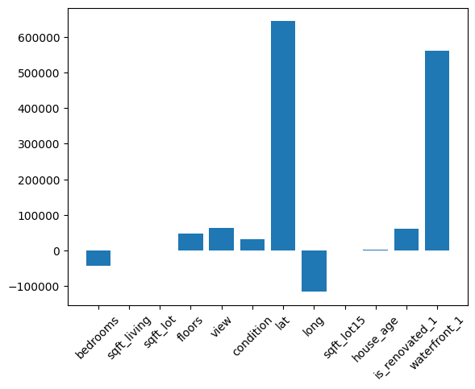

```python
from sklearn.linear_model import Lasso

X = df_cleaned.drop('price', axis=1).values
y = df_cleaned['price'].values
names = df_cleaned.drop('price', axis=1).columns
lasso = Lasso(alpha=0.1)
lasso_coef = lasso.fit(X, y).coef_
plt.bar(names, lasso_coef)
plt.xticks(rotation=45)
plt.show()
```

**Conclusion**

- Random Forest Regressor is the best model for predicting 'price'.
- It shows a clear improvement when compare with evaluate cross-validation peformance and simple baseline.
- Too many irrelevant features can cause the noise and degrade the performance.
- Overfitting and underfitting in the parameter grid can cause errors in the system.